# SCFA_Boxplots

Anna Michl

2026-01-27

Load all packages needed

```r
library(dplyr)
```

```r
library(readxl)
library(ggplot2)
library(ggpubr)  # for stats annotations
library(RColorBrewer)
library(viridis)
library(patchwork)
```

Set working directory (ADJUST TO YOUR PATH TO THE .XLSX FILE)

```r
setwd("C:/Users/annaj/Desktop/SCFAs_interlab_validation")
R.version
```

```
##                _
## platform       x86_64-w64-mingw32
## arch           x86_64
## os             mingw32
## crt            ucrt
## system         x86_64, mingw32
## status
## major          4
## minor          4.1
## year           2024
## month          06
## day            14
## svn rev        86737
## language       R
## version.string R version 4.4.1 (2024-06-14 ucrt)
## nickname       Race for Your Life
```

L A C T A T E

Import the dataset and exclude blanks

```r
lactate <- read_excel("NORWAY_QUANTIFICATION.xlsx", sheet = "NEW_LACTATE") %>%
  as.data.frame() %>%
  mutate(`MEDIAN_REL_AREA_NORMALIZED` = as.numeric(`MEDIAN_REL_AREA_NORMALIZED`)) %>%
  filter(COHORT != "Blank")  # Remove rows where COHORT is "Blank"
```

Filter only values Rep1 in the column replicate and exclude samples CV5 and CV6

```r
lactate <- lactate %>%
  filter(REPLICATE == "Rep1", !TYPE %in% c("CV5", "CV6"))
```

Define color palette

```r
N <- length(unique(lactate$TYPE))
desired_order <- c("GF_CZ", "Ba_CZ", "OMM12_CZ", "SPF_CZ", "GF_NO", "Ba_NO" , "OMM12_NO", "SPF_NO")
lactate$COHORT <- factor(lactate$COHORT, levels = desired_order)
```

Define comparison

```r
lactate_comparisons <- list(
  c("Ba_CZ", "OMM12_CZ"),
  c("Ba_NO", "OMM12_NO"),
  c("GF_CZ", "Ba_CZ"),
  c("GF_NO", "Ba_NO"),
  c("SPF_CZ", "OMM12_CZ"),
  c("SPF_NO", "OMM12_NO")
)
```

Select color palette for all the graphs

```r
my_palette_fill <- c("cornflowerblue", "orchid3", "maroon", "lightblue1" ,"cornflowerblue", "orchid3",  "maroon", "lightblue1")
my_palette_color <- c(
  "red4", "skyblue4", "navy", "goldenrod2", "darkolivegreen", "darkorange", "salmon", "violet", "lightsalmon3",
  "red4", "skyblue4", "goldenrod2", "darkolivegreen", "darkorange", "purple4", "lightyellow", "seagreen3", "indianred",
  "red4", "skyblue4", "navy", "goldenrod2",
  "red4" , "skyblue4",  "navy", "goldenrod2")
```

Remove zero or negative values

```r
lactate <- lactate %>% filter(`MEDIAN_REL_AREA_NORMALIZED` > 0)
lactate$COHORT <- factor(lactate$COHORT, levels = desired_order)
lactate$TYPE   <- factor(lactate$TYPE)
levels(lactate$COHORT)
```

```
## [1] "GF_CZ"    "Ba_CZ"    "OMM12_CZ" "SPF_CZ"   "GF_NO"    "Ba_NO"    "OMM12_NO"
## [8] "SPF_NO"
```

```r
levels(lactate$TYPE)
```

```
##  [1] "368-1" "368-2" "368-3" "368-4" "373-1" "373-2" "373-3" "373-4" "CV1"
## [10] "CV10"  "CV2"   "CV3"   "CV4"   "CV7"   "CV8"   "CV9"   "GF1"   "GF2"
## [19] "GF3"   "GF4"   "OMM1"  "OMM2"  "OMM3"  "OMM4"
```

Visualize the comparison with ggplot

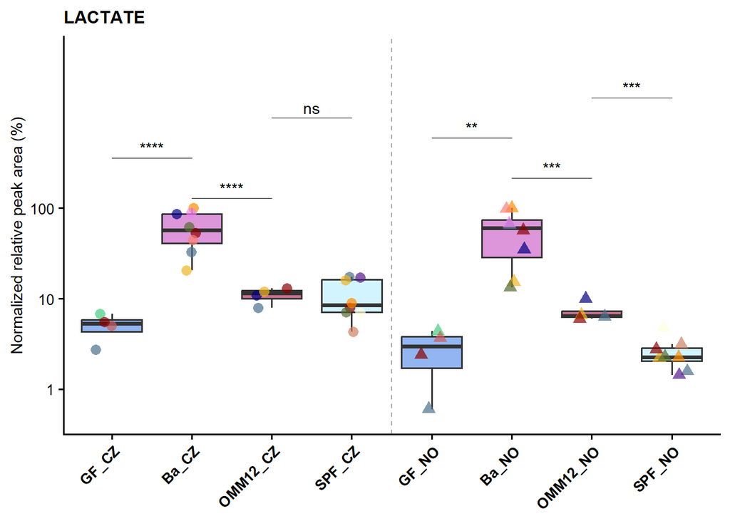

```r
ggplot(lactate, aes(x = COHORT, y = `MEDIAN_REL_AREA_NORMALIZED`, fill = COHORT)) +
  geom_boxplot(alpha = 0.7, outlier.shape = NA,show.legend = FALSE) +
  geom_vline(xintercept = 4.5, linetype = "dashed", linewidth = 0.5, color = "darkgrey") +
  geom_jitter(aes(color = TYPE, shape = COUNTRY), width = 0.2, size = 3, alpha = 0.7, show.legend = FALSE) +
  stat_compare_means(comparisons = lactate_comparisons,
                     method = "t.test",
                     p.adjust.method = "BH",
                     label = "p.signif",
                     tip.length = 0.00,
                     step.increase = 0.1) +
  scale_color_manual(values = my_palette_color) +
  scale_shape_manual(values = c("CZ" = 16, "NO" = 17)) +
  scale_fill_manual(values = my_palette_fill) +
  scale_y_log10(breaks = c(0.1, 1, 10, 100),
                labels = c("0.1", "1", "10", "100")) +
  coord_cartesian(ylim = c(0.5, 5000)) +  # keeps all points in view without dropping
  theme_classic(base_size = 14) +
   labs(title = "LACTATE", y = "Normalized relative peak area (%)")+
   theme(
    plot.title   = element_text(size = 12, face = "bold"),
    axis.title.x = element_blank(),
    axis.title.y = element_text(size = 11, colour = "black"),
    axis.text.x = element_text(size = 10, face = "bold", angle = 45, hjust = 1, colour = "black"),
    axis.text.y  = element_text(size = 10, colour = "black")
  )
```

Save as a variavble

```r
Lactate_boxplots<- ggplot(lactate, aes(x = COHORT, y = `MEDIAN_REL_AREA_NORMALIZED`, fill = COHORT)) +
  geom_boxplot(alpha = 0.7, outlier.shape = NA,show.legend = FALSE) +
  geom_vline(xintercept = 4.5, linetype = "dashed", linewidth = 0.5, color = "darkgrey") +
  geom_jitter(aes(color = TYPE, shape = COUNTRY), width = 0.2, size = 1.5, alpha = 0.7, show.legend = FALSE) +
  stat_compare_means(comparisons = lactate_comparisons,
                     method = "t.test",
                     p.adjust.method = "BH",
                     label = "p.signif",
                     tip.length = 0.00,
                     step.increase = 0.1) +
  scale_color_manual(values = my_palette_color) +
  scale_shape_manual(values = c("CZ" = 16, "NO" = 17)) +
  scale_fill_manual(values = my_palette_fill) +
  scale_y_log10(breaks = c(0.1, 1, 10, 100),
                labels = c("0.1", "1", "10", "100")) +
  coord_cartesian(ylim = c(0.5, 5000)) +  # keeps all points in view without dropping
  theme_classic(base_size = 14) +
  labs(title = "LACTATE", y = "Normalized relative peak area (%)")+
   theme(
    plot.title   = element_text(size = 12, face = "bold"),
    axis.title.x = element_blank(),
    axis.title.y = element_text(size = 11, colour = "black"),
    axis.text.x  = element_text(size = 10, face = "bold", angle = 45, hjust = 1, colour = "black"),
    axis.text.y  = element_text(size = 10, colour = "black")
  )
ggsave("Lactate_boxplots.png",
       plot = Lactate_boxplots,
       width = 10, height = 10, dpi = 300)
```

A C E T A T E

Import the dataset and exclude blanks

```r
acetate <- read_excel("NORWAY_QUANTIFICATION.xlsx", sheet = "NEW_ACETATE") %>%
  as.data.frame() %>%
  mutate(`MEDIAN_REL_AREA_NORMALIZED` = as.numeric(`MEDIAN_REL_AREA_NORMALIZED`)) %>%
  filter(COHORT != "Blank")  # Remove rows where COHORT is "Blank"
```

Filter only values Rep1 in the column replicate and exclude samples CV5 and CV6

```r
acetate <- acetate %>%
  filter(REPLICATE == "Rep1", !TYPE %in% c("CV5", "CV6"))
```

Define color palette

```r
N <- length(unique(acetate$TYPE))
acetate$COHORT <- factor(acetate$COHORT, levels = desired_order)
```

Define comparison

```r
acetate_comparisons <- list(
  c("GF_CZ", "Ba_CZ"),
  c("GF_NO", "Ba_NO"),
  c("Ba_CZ", "SPF_CZ"),
  c("Ba_NO", "SPF_NO"),
  c("GF_CZ", "OMM12_CZ"),
  c("GF_NO", "OMM12_NO"),
  c("SPF_CZ", "OMM12_CZ"),
  c("SPF_NO", "OMM12_NO")
)
```

Remove zero or negative values

```r
acetate <- acetate %>% filter(`MEDIAN_REL_AREA_NORMALIZED` > 0)
acetate$COHORT <- factor(acetate$COHORT, levels = desired_order)
acetate$TYPE   <- factor(acetate$TYPE)
levels(acetate$COHORT)
```

```
## [1] "GF_CZ"    "Ba_CZ"    "OMM12_CZ" "SPF_CZ"   "GF_NO"    "Ba_NO"    "OMM12_NO"
## [8] "SPF_NO"
```

```r
levels(acetate$TYPE)
```

```
##  [1] "368-1" "368-2" "368-3" "368-4" "373-1" "373-2" "373-3" "373-4" "CV1"
## [10] "CV10"  "CV2"   "CV3"   "CV4"   "CV7"   "CV8"   "CV9"   "GF1"   "GF2"
## [19] "GF3"   "GF4"   "OMM1"  "OMM2"  "OMM3"  "OMM4"
```

Visualize the comparison with ggplot

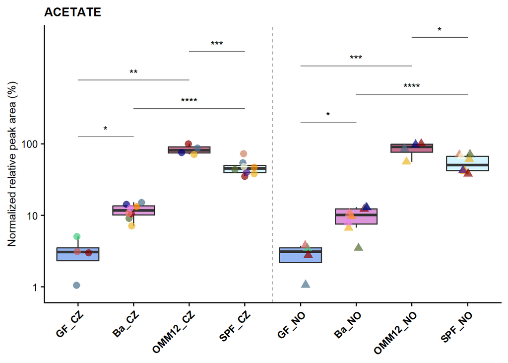

```r
ggplot(acetate, aes(x = COHORT, y = `MEDIAN_REL_AREA_NORMALIZED`, fill = COHORT)) +
  geom_boxplot(alpha = 0.7, outlier.shape = NA,show.legend = FALSE) +
  geom_vline(xintercept = 4.5, linetype = "dashed", linewidth = 0.5, color = "darkgrey") +
  geom_jitter(aes(color = TYPE, shape = COUNTRY), width = 0.2, size = 3, alpha = 0.7, show.legend = FALSE) +
  stat_compare_means(comparisons = acetate_comparisons,
                     method = "t.test",
                     label = "p.signif",
                    p.adjust.method = "BH",
                     tip.length = 0.0,
                     step.increase = 0.1) +
  scale_color_manual(values = my_palette_color) +
  scale_shape_manual(values = c("CZ" = 16, "NO" = 17)) +
  scale_fill_manual(values = my_palette_fill) +
  scale_y_log10(breaks = c(0.1, 1, 10, 100),
                labels = c("0.1", "1", "10", "100")) +
  coord_cartesian(ylim = c(0.9, 3000)) +  # keeps all points in view without dropping
  theme_classic(base_size = 14) +
  labs(title = "ACETATE", y = "Normalized relative peak area (%)")+
   theme(
    plot.title   = element_text(size = 12, face = "bold"),
    axis.title.x = element_blank(),
    axis.title.y = element_text(size = 11, colour = "black"),
    axis.text.x  = element_text(size = 10, face = "bold", angle = 45, hjust = 1, colour = "black"),
    axis.text.y  = element_text(size = 10, colour = "black")
  )
```

Save as a variavble

```r
Acetate_boxplots<- ggplot(acetate, aes(x = COHORT, y = `MEDIAN_REL_AREA_NORMALIZED`, fill = COHORT)) +
  geom_boxplot(alpha = 0.7, outlier.shape = NA,show.legend = FALSE) +
  geom_vline(xintercept = 4.5, linetype = "dashed", linewidth = 0.5, color = "darkgrey") +
  geom_jitter(aes(color = TYPE, shape = COUNTRY), width = 0.2, size = 1.5, alpha = 0.7, show.legend = FALSE) +
  stat_compare_means(comparisons = acetate_comparisons,
                     method = "t.test",
                      p.adjust.method = "BH",
                     label = "p.signif",
                     tip.length = 0.0,
                     step.increase = 0.1) +
  scale_color_manual(values = my_palette_color) +
  scale_shape_manual(values = c("CZ" = 16, "NO" = 17)) +
  scale_fill_manual(values = my_palette_fill) +
  scale_y_log10(breaks = c(0.1, 1, 10, 100),
                labels = c("0.1", "1", "10", "100")) +
  coord_cartesian(ylim = c(0.9, 5000)) +  # keeps all points in view without dropping
  theme_classic(base_size = 14) +
  labs(title = "ACETATE", y = "Normalized relative peak area (%)")+
   theme(
    plot.title   = element_text(size = 12, face = "bold"),
    axis.title.x = element_blank(),
    axis.title.y = element_text(size = 11, colour = "black"),
    axis.text.x  = element_text(size = 10, face = "bold", angle = 45, hjust = 1, colour = "black"),
    axis.text.y  = element_text(size = 10, colour = "black")
  )

ggsave("Acetate_boxplots.png",
       plot = Acetate_boxplots,
       width = 10, height = 10, dpi = 300)
```

P R O P I O N A T E

Import the dataset and exclude blanks

```r
propionate <- read_excel("NORWAY_QUANTIFICATION.xlsx", sheet = "NEW_PROPIONATE") %>%
  as.data.frame() %>%
  mutate(`MEDIAN_REL_AREA_NORMALIZED` = as.numeric(`MEDIAN_REL_AREA_NORMALIZED`)) %>%
  filter(COHORT != "Blank")  # Remove rows where COHORT is "Blank"
```

Filter only values Rep1 in the column replicate and exclude samples CV5 and CV6

```r
propionate <- propionate %>%
  filter(REPLICATE == "Rep1", !TYPE %in% c("CV5", "CV6"))
```

Define color palette

```r
N <- length(unique(propionate$TYPE))
propionate$COHORT <- factor(propionate$COHORT, levels = desired_order)
```

Define comparison

```r
propionate_comparisons <- list(
  c("GF_CZ", "Ba_CZ"),
  c("GF_NO", "Ba_NO"),
  c("Ba_CZ", "SPF_CZ"),
  c("Ba_NO", "SPF_NO"),
  c("GF_CZ", "OMM12_CZ"),
  c("GF_NO", "OMM12_NO"),
  c("SPF_CZ", "OMM12_CZ"),
  c("SPF_NO", "OMM12_NO")
)
```

Remove zero or negative values

```r
propionate <- propionate %>% filter(`MEDIAN_REL_AREA_NORMALIZED` > 0)
propionate$COHORT <- factor(propionate$COHORT, levels = desired_order)
propionate$TYPE   <- factor(propionate$TYPE)
levels(propionate$COHORT)
```

```
## [1] "GF_CZ"    "Ba_CZ"    "OMM12_CZ" "SPF_CZ"   "GF_NO"    "Ba_NO"    "OMM12_NO"
## [8] "SPF_NO"
```

```r
levels(propionate$TYPE)
```

```
##  [1] "368-1" "368-2" "368-3" "368-4" "373-1" "373-2" "373-3" "373-4" "CV1"
## [10] "CV10"  "CV2"   "CV3"   "CV4"   "CV7"   "CV8"   "CV9"   "GF1"   "GF2"
## [19] "GF3"   "GF4"   "OMM1"  "OMM2"  "OMM3"  "OMM4"
```

Visualize the comparison with ggplot

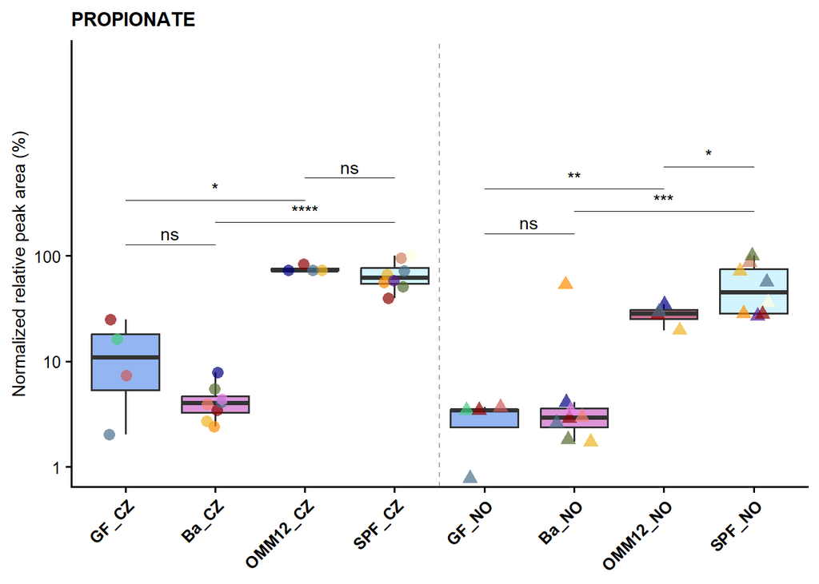

```r
ggplot(propionate, aes(x = COHORT, y = `MEDIAN_REL_AREA_NORMALIZED`, fill = COHORT)) +
  geom_boxplot(alpha = 0.7, outlier.shape = NA,show.legend = FALSE) +
  geom_vline(xintercept = 4.5, linetype = "dashed", linewidth = 0.5, color = "darkgrey") +
  geom_jitter(aes(color = TYPE, shape = COUNTRY), width = 0.2, size = 3, alpha = 0.7, show.legend = FALSE) +
  stat_compare_means(comparisons = propionate_comparisons,
                     method = "t.test",
                     p.adjust.method = "BH",
                     label = "p.signif",
                     tip.length = 0.0,
                     step.increase = 0.05) +
  scale_color_manual(values = my_palette_color) +
  scale_shape_manual(values = c("CZ" = 16, "NO" = 17)) +
  scale_fill_manual(values = my_palette_fill) +
  scale_y_log10(breaks = c(0.1, 1, 10, 100),
                labels = c("0.1", "1", "10", "100")) +
  coord_cartesian(ylim = c(1, 7000)) +
  theme_classic(base_size = 14) +
  labs(title = "PROPIONATE", y = "Normalized relative peak area (%)")+
   theme(
    plot.title   = element_text(size = 12, face = "bold"),
    axis.title.x = element_blank(),
    axis.title.y = element_text(size = 11, colour = "black"),
    axis.text.x  = element_text(size = 10, face = "bold", angle = 45, hjust = 1, colour = "black"),
    axis.text.y  = element_text(size = 10, colour = "black")
  )
```

Save as a variavble

```r
Propionate_boxplots<- ggplot(propionate, aes(x = COHORT, y = `MEDIAN_REL_AREA_NORMALIZED`, fill = COHORT)) +
  geom_boxplot(alpha = 0.7, outlier.shape = NA,show.legend = FALSE) +
  geom_vline(xintercept = 4.5, linetype = "dashed", linewidth = 0.5, color = "darkgrey") +
  geom_jitter(aes(color = TYPE, shape = COUNTRY), width = 0.2, size = 1.5, alpha = 0.7, show.legend = FALSE) +
  stat_compare_means(comparisons = propionate_comparisons,
                     method = "t.test",
                     label = "p.signif",
                     p.adjust.method = "BH",
                     tip.length = 0.0,
                     step.increase = 0.1) +
  scale_color_manual(values = my_palette_color) +
  scale_shape_manual(values = c("CZ" = 16, "NO" = 17)) +
  scale_fill_manual(values = my_palette_fill) +
  scale_y_log10(breaks = c(0.1, 1, 10, 100),
                labels = c("0.1", "1", "10", "100")) +
  coord_cartesian(ylim = c(1, 7000)) +
  theme_classic(base_size = 14) +
  labs(title = "PROPIONATE", y = "Normalized relative peak area (%)")+
   theme(
    plot.title   = element_text(size = 12, face = "bold"),
    axis.title.x = element_blank(),
    axis.title.y = element_text(size = 11, colour = "black"),
    axis.text.x  = element_text(size = 10, face = "bold", angle = 45, hjust = 1, colour = "black"),
    axis.text.y  = element_text(size = 10, colour = "black")
  )
ggsave("Propionate_boxplots.png",
       plot = Propionate_boxplots,
       width = 10, height = 10, dpi = 300)
```

B U T Y R A T E

Import the dataset and exclude blanks

```r
butyrate <- read_excel("NORWAY_QUANTIFICATION.xlsx", sheet = "NEW_BUTYRATE") %>%
  as.data.frame() %>%
  mutate(`MEDIAN_REL_AREA_NORMALIZED` = as.numeric(`MEDIAN_REL_AREA_NORMALIZED`)) %>%
  filter(COHORT != "Blank")  # Remove rows where COHORT is "Blank"
```

Filter only values Rep1 in the column replicate and exclude samples CV5 and CV6

```r
butyrate <- butyrate %>%
  filter(REPLICATE == "Rep1", !TYPE %in% c("CV5", "CV6"))
```

Define color palette

```r
N <- length(unique(butyrate$TYPE))
desired_order <- c("GF_CZ", "Ba_CZ", "OMM12_CZ", "SPF_CZ", "GF_NO", "Ba_NO" , "OMM12_NO", "SPF_NO")
butyrate$COHORT <- factor(butyrate$COHORT, levels = desired_order)
```

Define comparison

```r
butyrate_comparisons <- list(
  c("GF_CZ", "Ba_CZ"),
  c("GF_NO", "Ba_NO"),
  c("Ba_CZ", "OMM12_CZ"),
  c("Ba_NO", "OMM12_NO"),
  c("SPF_CZ", "OMM12_CZ"),
  c("SPF_NO", "OMM12_NO")
)
```

Remove zero or negative values

```r
butyrate <- butyrate %>% filter(`MEDIAN_REL_AREA_NORMALIZED` > 0)
butyrate$COHORT <- factor(butyrate$COHORT, levels = desired_order)
butyrate$TYPE   <- factor(butyrate$TYPE)    # color
levels(butyrate$COHORT)
```

```
## [1] "GF_CZ"    "Ba_CZ"    "OMM12_CZ" "SPF_CZ"   "GF_NO"    "Ba_NO"    "OMM12_NO"
## [8] "SPF_NO"
```

```r
levels(butyrate$TYPE)
```

```
##  [1] "368-1" "368-2" "368-3" "368-4" "373-1" "373-2" "373-3" "373-4" "CV1"
## [10] "CV10"  "CV2"   "CV3"   "CV4"   "CV7"   "CV8"   "CV9"   "GF1"   "GF2"
## [19] "GF3"   "GF4"   "OMM1"  "OMM2"  "OMM3"  "OMM4"
```

Visualize the comparison with ggplot

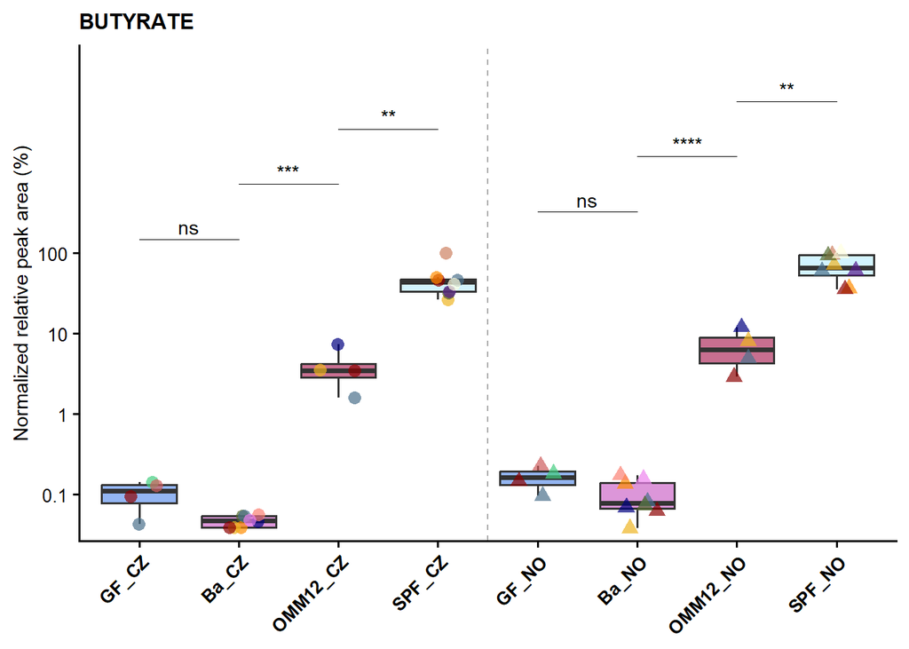

```r
ggplot(butyrate, aes(x = COHORT, y = `MEDIAN_REL_AREA_NORMALIZED`, fill = COHORT)) +
  geom_boxplot(alpha = 0.7, outlier.shape = NA,show.legend = FALSE) +
  geom_vline(xintercept = 4.5, linetype = "dashed", linewidth = 0.5, color = "darkgrey") +
  geom_jitter(aes(color = TYPE, shape = COUNTRY), width = 0.2, size = 3, alpha = 0.7, show.legend = FALSE) +
  stat_compare_means(comparisons = butyrate_comparisons,
                     method = "t.test",
                     label = "p.signif",
                     p.adjust.method = "BH",
                     tip.length = 0.0,
                     step.increase = 0.1) +
  scale_color_manual(values = my_palette_color) +
  scale_shape_manual(values = c("CZ" = 16, "NO" = 17)) +
  scale_fill_manual(values = my_palette_fill) +
  scale_y_log10(breaks = c(0.1, 1, 10, 100),
                labels = c("0.1", "1", "10", "100")) +
  coord_cartesian(ylim = c(0.05, 20000)) +  # keeps all points in view without dropping
  theme_classic(base_size = 14) +
  labs(title = "BUTYRATE", y = "Normalized relative peak area (%)")+
   theme(
    plot.title   = element_text(size = 12, face = "bold"),
    axis.title.x = element_blank(),
    axis.title.y = element_text(size = 11, colour = "black"),
    axis.text.x  = element_text(size = 10, face = "bold", angle = 45, hjust = 1, colour = "black"),
    axis.text.y  = element_text(size = 10, colour = "black")
  )
```

Save as a variavble

```r
Butyrate_boxplots<-ggplot(butyrate, aes(x = COHORT, y = `MEDIAN_REL_AREA_NORMALIZED`, fill = COHORT)) +
  geom_boxplot(alpha = 0.7, outlier.shape = NA,show.legend = FALSE) +
  geom_vline(xintercept = 4.5, linetype = "dashed", linewidth = 0.5, color = "darkgrey") +
  geom_jitter(aes(color = TYPE, shape = COUNTRY), width = 0.2, size = 1.5, alpha = 0.7, show.legend = FALSE) +
  stat_compare_means(comparisons = butyrate_comparisons,
                     method = "t.test",
                     label = "p.signif",
                     p.adjust.method = "BH",
                     tip.length = 0.0,
                     step.increase = 0.1) +
  scale_color_manual(values = my_palette_color) +
  scale_shape_manual(values = c("CZ" = 16, "NO" = 17)) +
  scale_fill_manual(values = my_palette_fill) +
  scale_y_log10(breaks = c(0.1, 1, 10, 100),
                labels = c("0.1", "1", "10", "100")) +
  coord_cartesian(ylim = c(0.05, 20000)) +  # keeps all points in view without dropping
  theme_classic(base_size = 14) +
  labs(title = "BUTYRATE", y = "Normalized relative peak area (%)")+
   theme(
    plot.title   = element_text(size = 12, face = "bold"),
    axis.title.x = element_blank(),
    axis.title.y = element_text(size = 11, colour = "black"),
    axis.text.x  = element_text(size = 10, face = "bold", angle = 45, hjust = 1, colour = "black"),
    axis.text.y  = element_text(size = 10, colour = "black")
  )
ggsave("Butyrate_boxplots.png",
       plot = Butyrate_boxplots,
       width = 10, height = 10, dpi = 300)
```

I S O B U T Y R A T E

Import the dataset and exclude blanks

```r
isobutyrate <- read_excel("NORWAY_QUANTIFICATION.xlsx", sheet = "NEW_ISOBUTYRATE") %>%
  as.data.frame() %>%
  mutate(`MEDIAN_REL_AREA_NORMALIZED` = as.numeric(`MEDIAN_REL_AREA_NORMALIZED`)) %>%
  filter(COHORT != "Blank")  # Remove rows where COHORT is "Blank"
```

Filter only values Rep1 in the column replicate and exclude samples CV5 and CV6

```r
isobutyrate <- isobutyrate %>%
  filter(REPLICATE == "Rep1", !TYPE %in% c("CV5", "CV6"))
```

Define color palette

```r
N <- length(unique(isobutyrate$TYPE))
desired_order <- c("GF_CZ", "Ba_CZ", "OMM12_CZ", "SPF_CZ", "GF_NO", "Ba_NO" , "OMM12_NO", "SPF_NO")
isobutyrate$COHORT <- factor(isobutyrate$COHORT, levels = desired_order)
```

Define comparison

```r
isobutyrate_comparisons <- list(
  c("GF_CZ", "Ba_CZ"),
  c("GF_NO", "Ba_NO"),
  c("Ba_CZ", "OMM12_CZ"),
  c("Ba_NO", "OMM12_NO"),
  c("SPF_CZ", "OMM12_CZ"),
  c("SPF_NO", "OMM12_NO")
)
```

Remove zero or negative values

```r
isobutyrate <- isobutyrate %>% filter(`MEDIAN_REL_AREA_NORMALIZED` > 0)
isobutyrate$COHORT <- factor(isobutyrate$COHORT, levels = desired_order)
isobutyrate$TYPE   <- factor(isobutyrate$TYPE)    # color
levels(isobutyrate$COHORT)  # should match your fill vector length
```

```
## [1] "GF_CZ"    "Ba_CZ"    "OMM12_CZ" "SPF_CZ"   "GF_NO"    "Ba_NO"    "OMM12_NO"
## [8] "SPF_NO"
```

```r
levels(isobutyrate$TYPE)    # should match your color vector length
```

```
##  [1] "368-1" "368-2" "368-3" "368-4" "373-1" "373-2" "373-3" "373-4" "CV1"
## [10] "CV10"  "CV2"   "CV3"   "CV4"   "CV7"   "CV8"   "CV9"   "GF1"   "GF2"
## [19] "GF3"   "GF4"   "OMM1"  "OMM2"  "OMM3"  "OMM4"
```

Visualize the comparison with ggplot

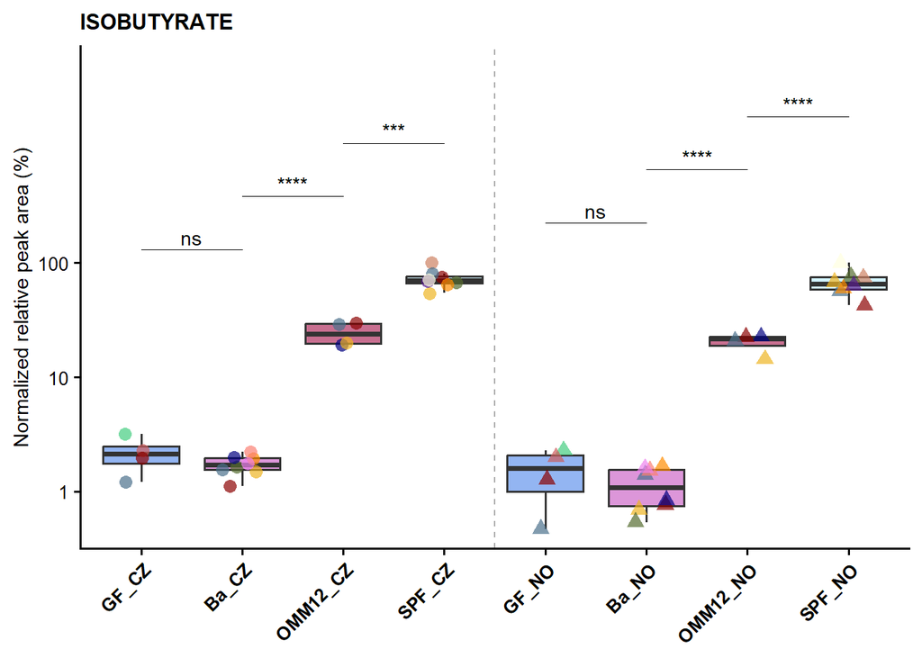

```r
ggplot(isobutyrate, aes(x = COHORT, y = `MEDIAN_REL_AREA_NORMALIZED`, fill = COHORT)) +
  geom_boxplot(alpha = 0.7, outlier.shape = NA,show.legend = FALSE) +
  geom_vline(xintercept = 4.5, linetype = "dashed", linewidth = 0.5, color = "darkgrey") +
  geom_jitter(aes(color = TYPE, shape = COUNTRY), width = 0.2, size = 3, alpha = 0.7, show.legend = FALSE) +
  stat_compare_means(comparisons = isobutyrate_comparisons,
                     method = "t.test",
                     label = "p.signif",
                     p.adjust.method = "BH",
                     tip.length = 0.0,
                     step.increase = 0.1) +
  scale_color_manual(values = my_palette_color) +
  scale_shape_manual(values = c("CZ" = 16, "NO" = 17)) +
  scale_fill_manual(values = my_palette_fill) +
  scale_y_log10(breaks = c(0.1, 1, 10, 100),
                labels = c("0.1", "1", "10", "100")) +
  coord_cartesian(ylim = c(0.5, 5000)) +  # keeps all points in view without dropping
  theme_classic(base_size = 14) +
  labs(title = "ISOBUTYRATE", y = "Normalized relative peak area (%)")+
   theme(
    plot.title   = element_text(size = 12, face = "bold"),
    axis.title.x = element_blank(),
    axis.title.y = element_text(size = 11, colour = "black"),
    axis.text.x  = element_text(size = 10, face = "bold", angle = 45, hjust = 1, colour = "black"),
    axis.text.y  = element_text(size = 10, colour = "black")
  )
```

Save as a variavble

```r
Isobutyrate_boxplots<- ggplot(isobutyrate, aes(x = COHORT, y = `MEDIAN_REL_AREA_NORMALIZED`, fill = COHORT)) +
  geom_boxplot(alpha = 0.7, outlier.shape = NA,show.legend = FALSE) +
  geom_vline(xintercept = 4.5, linetype = "dashed", linewidth = 0.5, color = "darkgrey") +
  geom_jitter(aes(color = TYPE, shape = COUNTRY), width = 0.2, size = 1.5, alpha = 0.7, show.legend = FALSE) +
  stat_compare_means(comparisons = isobutyrate_comparisons,
                     method = "t.test",
                     label = "p.signif",
                     p.adjust.method = "BH",
                     tip.length = 0.0,
                     step.increase = 0.1) +
  scale_color_manual(values = my_palette_color) +
  scale_shape_manual(values = c("CZ" = 16, "NO" = 17)) +
  scale_fill_manual(values = my_palette_fill) +
  scale_y_log10(breaks = c(0.1, 1, 10, 100),
                labels = c("0.1", "1", "10", "100")) +
  coord_cartesian(ylim = c(0.5, 5000)) +  # keeps all points in view without dropping
  theme_classic(base_size = 14) +
  labs(title = "ISOBUTYRATE", y = "Normalized relative peak area (%)")+
   theme(
    plot.title   = element_text(size = 12, face = "bold"),
    axis.title.x = element_blank(),
    axis.title.y = element_text(size = 11, colour = "black"),
    axis.text.x  = element_text(size = 10, face = "bold", angle = 45, hjust = 1, colour = "black"),
    axis.text.y  = element_text(size = 10, colour = "black")
  )
ggsave("Isobutyrate_boxplots.png",
       plot = Isobutyrate_boxplots,
       width = 10, height = 10, dpi = 300)
```

V A L E R A T E

Import the dataset and exclude blanks

```r
valerate <- read_excel("NORWAY_QUANTIFICATION.xlsx", sheet = "NEW_VALERATE") %>%
  as.data.frame() %>%
  mutate(`MEDIAN_REL_AREA_NORMALIZED` = as.numeric(`MEDIAN_REL_AREA_NORMALIZED`)) %>%
  filter(COHORT != "Blank")  # Remove rows where COHORT is "Blank"
```

Filter only values Rep1 in the column replicate and exclude samples CV5 and CV6

```r
valerate <- valerate %>%
  filter(REPLICATE == "Rep1", !TYPE %in% c("CV5", "CV6"))
```

Define color palette

```r
N <- length(unique(valerate$TYPE))
desired_order <- c("GF_CZ", "Ba_CZ", "OMM12_CZ", "SPF_CZ", "GF_NO", "Ba_NO" , "OMM12_NO", "SPF_NO")
valerate$COHORT <- factor(valerate$COHORT, levels = desired_order)
```

Define comparison

```r
valerate_comparisons <- list(
  c("GF_CZ", "Ba_CZ"),
  c("GF_NO", "Ba_NO"),
  c("Ba_CZ", "OMM12_CZ"),
  c("Ba_NO", "OMM12_NO"),
  c("Ba_CZ", "SPF_CZ"),
  c("Ba_NO", "SPF_NO")
)
```

Remove zero or negative values

```r
valerate <- valerate %>% filter(`MEDIAN_REL_AREA_NORMALIZED` > 0)
valerate$COHORT <- factor(valerate$COHORT, levels = desired_order)
valerate$TYPE   <- factor(valerate$TYPE)    # color
levels(valerate$COHORT)  # should match your fill vector length
```

```
## [1] "GF_CZ"    "Ba_CZ"    "OMM12_CZ" "SPF_CZ"   "GF_NO"    "Ba_NO"    "OMM12_NO"
## [8] "SPF_NO"
```

```r
levels(valerate$TYPE)    # should match your color vector length
```

```
##  [1] "368-1" "368-2" "368-3" "368-4" "373-1" "373-2" "373-3" "373-4" "CV1"
## [10] "CV10"  "CV2"   "CV3"   "CV4"   "CV7"   "CV8"   "CV9"   "GF1"   "GF2"
## [19] "GF3"   "GF4"   "OMM1"  "OMM2"  "OMM3"  "OMM4"
```

Visualize the comparison with ggplot

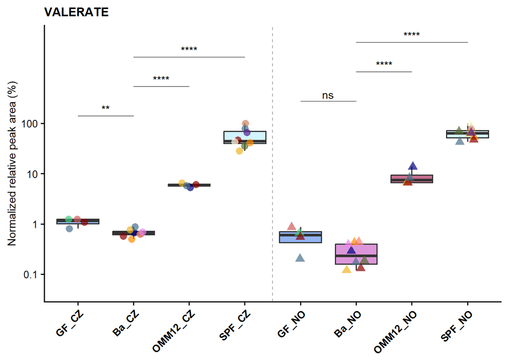

```r
ggplot(valerate, aes(x = COHORT, y = `MEDIAN_REL_AREA_NORMALIZED`, fill = COHORT)) +
  geom_boxplot(alpha = 0.7, outlier.shape = NA,show.legend = FALSE) +
  geom_vline(xintercept = 4.5, linetype = "dashed", linewidth = 0.5, color = "darkgrey") +
  geom_jitter(aes(color = TYPE, shape = COUNTRY), width = 0.2, size = 3, alpha = 0.7, show.legend = FALSE) +
  stat_compare_means(comparisons = valerate_comparisons,
                     method = "t.test",
                     label = "p.signif",
                     p.adjust.method = "BH",
                     tip.length = 0.00,
                     step.increase = 0.1) +
  scale_color_manual(values = my_palette_color) +
  scale_shape_manual(values = c("CZ" = 16, "NO" = 17)) +
  scale_fill_manual(values = my_palette_fill) +
  scale_y_log10(breaks = c(0.1, 1, 10, 100),
                labels = c("0.1", "1", "10", "100")) +
  coord_cartesian(ylim = c(0.05, 5000)) +  # keeps all points in view without dropping
  theme_classic(base_size = 14) +
   labs(title = "VALERATE", y = "Normalized relative peak area (%)")+
   theme(
    plot.title   = element_text(size = 12, face = "bold"),
    axis.title.x = element_blank(),
    axis.title.y = element_text(size = 11, colour = "black"),
    axis.text.x  = element_text(size = 10, face = "bold", angle = 45, hjust = 1, colour = "black"),
    axis.text.y  = element_text(size = 10, colour = "black")
  )
```

Save as a variavble

```r
Valerate_boxplots<-ggplot(valerate, aes(x = COHORT, y = `MEDIAN_REL_AREA_NORMALIZED`, fill = COHORT)) +
  geom_boxplot(alpha = 0.7, outlier.shape = NA,show.legend = FALSE) +
  geom_vline(xintercept = 4.5, linetype = "dashed", linewidth = 0.5, color = "darkgrey") +
  geom_jitter(aes(color = TYPE, shape = COUNTRY), width = 0.2, size = 1.5, alpha = 0.7, show.legend = FALSE) +
  stat_compare_means(comparisons = valerate_comparisons,
                     method = "t.test",
                     label = "p.signif",
                     p.adjust.method = "BH",
                     tip.length = 0.00,
                     step.increase = 0.1) +
  scale_color_manual(values = my_palette_color) +
  scale_shape_manual(values = c("CZ" = 16, "NO" = 17)) +
  scale_fill_manual(values = my_palette_fill) +
  scale_y_log10(breaks = c(0.1, 1, 10, 100),
                labels = c("0.1", "1", "10", "100")) +
  coord_cartesian(ylim = c(0.05, 5000)) +  # keeps all points in view without dropping
  theme_classic(base_size = 14) +
   labs(title = "VALERATE", y = "Normalized relative peak area (%)")+
   theme(
    plot.title   = element_text(size = 12, face = "bold"),
    axis.title.x = element_blank(),
    axis.title.y = element_text(size = 11, colour = "black"),
    axis.text.x  = element_text(size = 10, face = "bold", angle = 45, hjust = 1, colour = "black"),
    axis.text.y  = element_text(size = 10, colour = "black")
  )
ggsave("Valerate_boxplots.png",
       plot = Valerate_boxplots,
       width = 10, height = 10, dpi = 300)
```

I S O V A L E R A T E

Import the dataset and exclude blanks

```r
isovalerate <- read_excel("NORWAY_QUANTIFICATION.xlsx", sheet = "NEW_ISOVALERATE") %>%
  as.data.frame() %>%
  mutate(`MEDIAN_REL_AREA_NORMALIZED` = as.numeric(`MEDIAN_REL_AREA_NORMALIZED`)) %>%
  filter(COHORT != "Blank")  # Remove rows where COHORT is "Blank"
```

Filter only values Rep1 in the column replicate and exclude samples CV5 and CV6

```r
isovalerate <- isovalerate %>%
  filter(REPLICATE == "Rep1", !TYPE %in% c("CV5", "CV6"))
```

Define color palette

```r
N <- length(unique(isovalerate$TYPE))
desired_order <- c("GF_CZ", "Ba_CZ", "OMM12_CZ", "SPF_CZ", "GF_NO", "Ba_NO" , "OMM12_NO", "SPF_NO")
isovalerate$COHORT <- factor(isovalerate$COHORT, levels = desired_order)
```

Define comparison

```r
isovalerate_comparisons <- list(
  c("GF_CZ", "Ba_CZ"),
  c("GF_NO", "Ba_NO"),
  c("Ba_CZ", "OMM12_CZ"),
  c("Ba_NO", "OMM12_NO"),
  c("SPF_CZ", "OMM12_CZ"),
  c("SPF_NO", "OMM12_NO")
)
```

Remove zero or negative values

```r
isovalerate <- isovalerate %>% filter(`MEDIAN_REL_AREA_NORMALIZED` > 0)
isovalerate$COHORT <- factor(isovalerate$COHORT, levels = desired_order)
isovalerate$TYPE   <- factor(isovalerate$TYPE)    # color
levels(isovalerate$COHORT)  # should match your fill vector length
```

```
## [1] "GF_CZ"    "Ba_CZ"    "OMM12_CZ" "SPF_CZ"   "GF_NO"    "Ba_NO"    "OMM12_NO"
## [8] "SPF_NO"
```

```r
levels(isovalerate$TYPE)    # should match your color vector length
```

```
##  [1] "368-1" "368-2" "368-3" "368-4" "373-1" "373-2" "373-3" "373-4" "CV1"
## [10] "CV10"  "CV2"   "CV3"   "CV4"   "CV7"   "CV8"   "CV9"   "GF1"   "GF2"
## [19] "GF3"   "GF4"   "OMM1"  "OMM2"  "OMM3"  "OMM4"
```

Visualize the comparison with ggplot

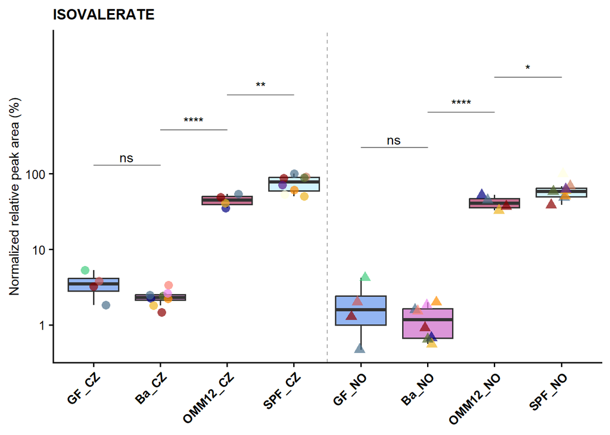

```r
ggplot(isovalerate, aes(x = COHORT, y = `MEDIAN_REL_AREA_NORMALIZED`, fill = COHORT)) +
  geom_boxplot(alpha = 0.7, outlier.shape = NA,show.legend = FALSE) +
  geom_vline(xintercept = 4.5, linetype = "dashed", linewidth = 0.5, color = "darkgrey") +
  geom_jitter(aes(color = TYPE, shape = COUNTRY), width = 0.2, size = 3, alpha = 0.7, show.legend = FALSE) +
  stat_compare_means(comparisons = isovalerate_comparisons,
                     method = "t.test",
                     label = "p.signif",
                     p.adjust.method = "BH",
                     tip.length = 0.00,
                     step.increase = 0.1) +
  scale_color_manual(values = my_palette_color) +
  scale_shape_manual(values = c("CZ" = 16, "NO" = 17)) +
  scale_fill_manual(values = my_palette_fill) +
  scale_y_log10(breaks = c(0.1, 1, 10, 100),
                labels = c("0.1", "1", "10", "100")) +
  coord_cartesian(ylim = c(0.5, 5000)) +  # keeps all points in view without dropping
  theme_classic(base_size = 14) +
  labs(title = "ISOVALERATE", y = "Normalized relative peak area (%)")+
   theme(
    plot.title   = element_text(size = 12, face = "bold"),
    axis.title.x = element_blank(),
    axis.title.y = element_text(size = 11, colour = "black"),
    axis.text.x  = element_text(size = 10, face = "bold", angle = 45, hjust = 1, colour = "black"),
    axis.text.y  = element_text(size = 10, colour = "black")
  )
```

Save as a variavble

```r
Isovalerate_boxplots<- ggplot(isovalerate, aes(x = COHORT, y = `MEDIAN_REL_AREA_NORMALIZED`, fill = COHORT)) +
  geom_boxplot(alpha = 0.7, outlier.shape = NA,show.legend = FALSE) +
  geom_vline(xintercept = 4.5, linetype = "dashed", linewidth = 0.5, color = "darkgrey") +
  geom_jitter(aes(color = TYPE, shape = COUNTRY), width = 0.2, size = 1.5, alpha = 0.7, show.legend = FALSE) +
  stat_compare_means(comparisons = isovalerate_comparisons,
                     method = "t.test",
                     label = "p.signif",
                     p.adjust.method = "BH",
                     tip.length = 0.00,
                     step.increase = 0.1) +
  scale_color_manual(values = my_palette_color) +
  scale_shape_manual(values = c("CZ" = 16, "NO" = 17)) +
  scale_fill_manual(values = my_palette_fill) +
  scale_y_log10(breaks = c(0.1, 1, 10, 100),
                labels = c("0.1", "1", "10", "100")) +
  coord_cartesian(ylim = c(0.5, 5000)) +  # keeps all points in view without dropping
  theme_classic(base_size = 14) +
  labs(title = "ISOVALERATE/METHYL ISOBUYRATE", y = "Normalized relative peak area (%)")+
   theme(
    plot.title   = element_text(size = 12, face = "bold"),
    axis.title.x = element_blank(),
    axis.title.y = element_text(size = 11, colour = "black"),
    axis.text.x  = element_text(size = 10, face = "bold", angle = 45, hjust = 1, colour = "black"),
    axis.text.y  = element_text(size = 10, colour = "black")
  )
ggsave("Isovalerate_boxplots.png",
       plot = Isovalerate_boxplots,
       width = 10, height = 10, dpi = 300)
```

P I V A L A T E

Import the dataset and exclude blanks

```r
pivalate <- read_excel("NORWAY_QUANTIFICATION.xlsx", sheet = "NEW_PIVALATE") %>%
  as.data.frame() %>%
  mutate(`MEDIAN_REL_AREA_NORMALIZED` = as.numeric(`MEDIAN_REL_AREA_NORMALIZED`)) %>%
  filter(COHORT != "Blank")  # Remove rows where COHORT is "Blank"
```

Filter only values Rep1 in the column replicate and exclude samples CV5 and CV6

```r
pivalate <- pivalate %>%
  filter(REPLICATE == "Rep1", !TYPE %in% c("CV5", "CV6"))
```

Define color palette

```r
N <- length(unique(pivalate$TYPE))
desired_order <- c("GF_CZ", "Ba_CZ", "OMM12_CZ", "SPF_CZ", "GF_NO", "Ba_NO" , "OMM12_NO", "SPF_NO")
pivalate$COHORT <- factor(pivalate$COHORT, levels = desired_order)
```

Define comparison

```r
pivalate_comparisons <- list(
  c("GF_CZ", "Ba_CZ"),
  c("GF_NO", "Ba_NO"),
  c("Ba_CZ", "OMM12_CZ"),
  c("Ba_NO", "OMM12_NO"),
  c("SPF_CZ", "OMM12_CZ"),
  c("SPF_NO", "OMM12_NO")
)
```

Remove zero or negative values

```r
pivalate <- pivalate %>% filter(`MEDIAN_REL_AREA_NORMALIZED` > 0)
pivalate$COHORT <- factor(pivalate$COHORT, levels = desired_order)
pivalate$TYPE   <- factor(pivalate$TYPE)    # color
levels(pivalate$COHORT)  # should match your fill vector length
```

```
## [1] "GF_CZ"    "Ba_CZ"    "OMM12_CZ" "SPF_CZ"   "GF_NO"    "Ba_NO"    "OMM12_NO"
## [8] "SPF_NO"
```

```r
levels(pivalate$TYPE)    # should match your color vector length
```

```
##  [1] "368-1" "368-2" "368-3" "368-4" "373-1" "373-2" "373-3" "373-4" "CV1"
## [10] "CV10"  "CV2"   "CV3"   "CV4"   "CV7"   "CV8"   "CV9"   "GF1"   "GF2"
## [19] "GF3"   "GF4"   "OMM1"  "OMM2"  "OMM3"  "OMM4"
```

Visualize the comparison with ggplot

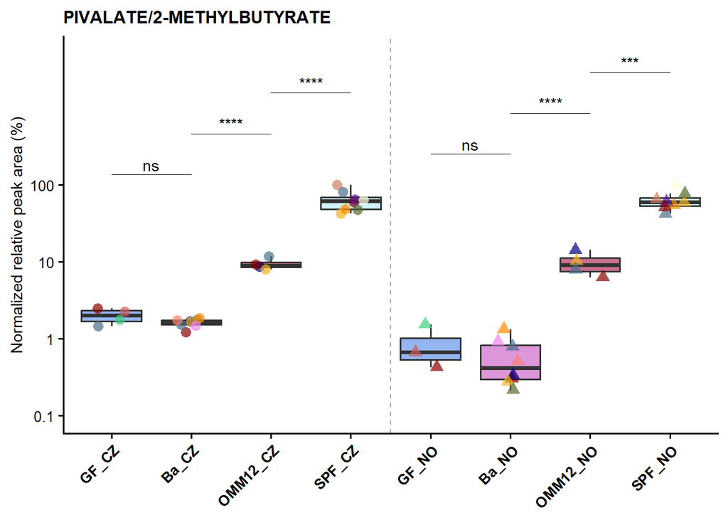

```r
ggplot(pivalate, aes(x = COHORT, y = `MEDIAN_REL_AREA_NORMALIZED`, fill = COHORT)) +
  geom_boxplot(alpha = 0.7, outlier.shape = NA,show.legend = FALSE) +
  geom_vline(xintercept = 4.5, linetype = "dashed", linewidth = 0.5, color = "darkgrey") +
  geom_jitter(aes(color = TYPE, shape = COUNTRY), width = 0.2, size = 3, alpha = 0.7, show.legend = FALSE) +
  stat_compare_means(comparisons = pivalate_comparisons,
                     method = "t.test",
                     label = "p.signif",
                     p.adjust.method = "BH",
                     tip.length = 0.00,
                     step.increase = 0.1) +
  scale_color_manual(values = my_palette_color) +
  scale_shape_manual(values = c("CZ" = 16, "NO" = 17)) +
  scale_fill_manual(values = my_palette_fill) +
  scale_y_log10(breaks = c(0.1, 1, 10, 100),
                labels = c("0.1", "1", "10", "100")) +
  coord_cartesian(ylim = c(0.1, 5000)) +  # keeps all points in view without dropping
  theme_classic(base_size = 14) +
  labs(title = "PIVALATE/2-METHYLBUTYRATE", y = "Normalized relative peak area (%)")+
   theme(
    plot.title   = element_text(size = 12, face = "bold"),
    axis.title.x = element_blank(),
    axis.title.y = element_text(size = 11, colour = "black"),
    axis.text.x  = element_text(size = 10, face = "bold", angle = 45, hjust = 1, colour = "black"),
    axis.text.y  = element_text(size = 10, colour = "black")
  )
```

Save as a variavble

```r
Pivalate_boxplots<- ggplot(pivalate, aes(x = COHORT, y = `MEDIAN_REL_AREA_NORMALIZED`, fill = COHORT)) +
  geom_boxplot(alpha = 0.7, outlier.shape = NA,show.legend = FALSE) +
  geom_vline(xintercept = 4.5, linetype = "dashed", linewidth = 0.5, color = "darkgrey") +
  geom_jitter(aes(color = TYPE, shape = COUNTRY), width = 0.2, size = 1.5, alpha = 0.7, show.legend = FALSE) +
  stat_compare_means(comparisons = pivalate_comparisons,
                     method = "t.test",
                     label = "p.signif",
                     p.adjust.method = "BH",
                     tip.length = 0.00,
                     step.increase = 0.1) +
  scale_color_manual(values = my_palette_color) +
  scale_shape_manual(values = c("CZ" = 16, "NO" = 17)) +
  scale_fill_manual(values = my_palette_fill) +
  scale_y_log10(breaks = c(0.1, 1, 10, 100),
                labels = c("0.1", "1", "10", "100")) +
  coord_cartesian(ylim = c(0.1, 5000)) +  # keeps all points in view without dropping
  theme_classic(base_size = 14) +
  labs(title = "PIVALATE/2-METHYLBUTYRATE", y = "Normalized relative peak area (%)")+
   theme(
    plot.title   = element_text(size = 12, face = "bold"),
    axis.title.x = element_blank(),
    axis.title.y = element_text(size = 11, colour = "black"),
    axis.text.x  = element_text(size = 10, face = "bold", angle = 45, hjust = 1, colour = "black"),
    axis.text.y  = element_text(size = 10, colour = "black")
  )
ggsave("Pivalate_boxplots.png",
       plot = Pivalate_boxplots,
       width = 10, height = 10, dpi = 300)
```

C I T R A T E

Import the dataset and exclude blanks

```r
citrate <- read_excel("NORWAY_QUANTIFICATION.xlsx", sheet = "NEW_CITRATE") %>%
  as.data.frame() %>%
  mutate(`MEDIAN_REL_AREA_NORMALIZED` = as.numeric(`MEDIAN_REL_AREA_NORMALIZED`)) %>%
  filter(COHORT != "Blank")  # Remove rows where COHORT is "Blank"
```

Filter only values Rep1 in the column replicate and exclude samples CV5 and CV6

```r
citrate <- citrate %>%
  filter(REPLICATE == "Rep1", !TYPE %in% c("CV5", "CV6"))
```

Define color palette

```r
N <- length(unique(citrate$TYPE))
desired_order <- c("GF_CZ", "Ba_CZ", "OMM12_CZ", "SPF_CZ", "GF_NO", "Ba_NO" , "OMM12_NO", "SPF_NO")
citrate$COHORT <- factor(citrate$COHORT, levels = desired_order)
```

Define comparison

```r
citrate_comparisons <- list(
  c("GF_CZ", "Ba_CZ"),
  c("GF_NO", "Ba_NO"),
  c("Ba_CZ", "OMM12_CZ"),
  c("Ba_NO", "OMM12_NO"),
  c("SPF_CZ", "OMM12_CZ"),
  c("SPF_NO", "OMM12_NO")
)
```

Remove zero or negative values

```r
citrate <- citrate %>% filter(`MEDIAN_REL_AREA_NORMALIZED` > 0)
citrate$COHORT <- factor(citrate$COHORT, levels = desired_order)
citrate$TYPE   <- factor(citrate$TYPE)    # color
levels(citrate$COHORT)  # should match your fill vector length
```

```
## [1] "GF_CZ"    "Ba_CZ"    "OMM12_CZ" "SPF_CZ"   "GF_NO"    "Ba_NO"    "OMM12_NO"
## [8] "SPF_NO"
```

```r
levels(citrate$TYPE)    # should match your color vector length
```

```
##  [1] "368-1" "368-2" "368-3" "368-4" "373-1" "373-2" "373-3" "373-4" "CV1"
## [10] "CV10"  "CV2"   "CV3"   "CV4"   "CV7"   "CV8"   "CV9"   "GF1"   "GF2"
## [19] "GF3"   "GF4"   "OMM1"  "OMM2"  "OMM3"  "OMM4"
```

Visualize the comparison with ggplot

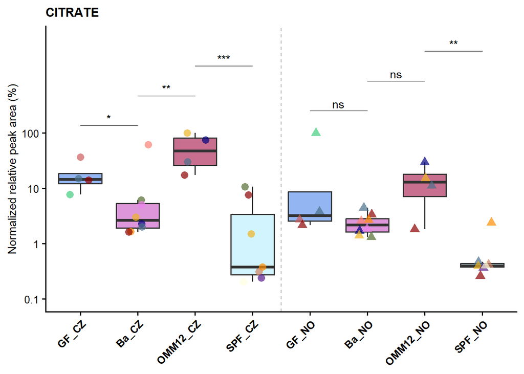

```r
ggplot(citrate, aes(x = COHORT, y = `MEDIAN_REL_AREA_NORMALIZED`, fill = COHORT)) +
  geom_boxplot(alpha = 0.7, outlier.shape = NA,show.legend = FALSE) +
  geom_vline(xintercept = 4.5, linetype = "dashed", linewidth = 0.5, color = "darkgrey") +
  geom_jitter(aes(color = TYPE, shape = COUNTRY), width = 0.2, size = 3, alpha = 0.7, show.legend = FALSE) +
  stat_compare_means(comparisons = citrate_comparisons,
                     method = "t.test",
                     label = "p.signif",
                     p.adjust.method = "BH",
                     tip.length = 0.00,
                     step.increase = 0.1) +
  scale_color_manual(values = my_palette_color) +
  scale_shape_manual(values = c("CZ" = 16, "NO" = 17)) +
  scale_fill_manual(values = my_palette_fill) +
  scale_y_log10(breaks = c(0.1, 1, 10, 100),
                labels = c("0.1", "1", "10", "100")) +
  coord_cartesian(ylim = c(0.1, 5000)) +  # keeps all points in view without dropping
  theme_classic(base_size = 14) +
  labs(title = "CITRATE", y = "Normalized relative peak area (%)")+
   theme(
    plot.title   = element_text(size = 12, face = "bold"),
    axis.title.x = element_blank(),
    axis.title.y = element_text(size = 11, colour = "black"),
    axis.text.x  = element_text(size = 10, face = "bold", angle = 45, hjust = 1, colour = "black"),
    axis.text.y  = element_text(size = 10, colour = "black")
  )
```

Save as a variavble

```r
Citrate_boxplots<-ggplot(citrate, aes(x = COHORT, y = `MEDIAN_REL_AREA_NORMALIZED`, fill = COHORT)) +
  geom_boxplot(alpha = 0.7, outlier.shape = NA,show.legend = FALSE) +
  geom_vline(xintercept = 4.5, linetype = "dashed", linewidth = 0.5, color = "darkgrey") +
  geom_jitter(aes(color = TYPE, shape = COUNTRY), width = 0.2, size = 1.5, alpha = 0.7, show.legend = FALSE) +
  stat_compare_means(comparisons = citrate_comparisons,
                     method = "t.test",
                     label = "p.signif",
                     p.adjust.method = "BH",
                     tip.length = 0.00,
                     step.increase = 0.1) +
  scale_color_manual(values = my_palette_color) +
  scale_shape_manual(values = c("CZ" = 16, "NO" = 17)) +
  scale_fill_manual(values = my_palette_fill) +
  scale_y_log10(breaks = c(0.1, 1, 10, 100),
                labels = c("0.1", "1", "10", "100")) +
  coord_cartesian(ylim = c(0.1, 5000)) +  # keeps all points in view without dropping
  theme_classic(base_size = 14) +
  labs(title = "CITRATE", y = "Normalized relative peak area (%)")+
   theme(
    plot.title   = element_text(size = 12, face = "bold"),
    axis.title.x = element_blank(),
    axis.title.y = element_text(size = 11, colour = "black"),
    axis.text.x  = element_text(size = 10, face = "bold", angle = 45, hjust = 1, colour = "black"),
    axis.text.y  = element_text(size = 10, colour = "black")
  )
ggsave("Citrate_boxplots.png",
       plot = Citrate_boxplots,
       width = 10, height = 10, dpi = 300)
```

M A L A T E

Import the dataset and exclude blanks

```r
malate <- read_excel("NORWAY_QUANTIFICATION.xlsx", sheet = "NEW_MALATE") %>%
  as.data.frame() %>%
  mutate(`conc_mmol/mg` = as.numeric(`conc_mmol/mg`)) %>%
  filter(COHORT != "Blank")  # Remove rows where COHORT is "Blank"
```

Filter only values Rep1 in the column replicate and exclude samples CV5 and CV6

```r
malate <- malate %>%
  filter(REPLICATE == "Rep1", !TYPE %in% c("CV5", "CV6"))
```

Define color palette

```r
N <- length(unique(malate$TYPE))
desired_order <- c("GF_CZ", "Ba_CZ", "OMM12_CZ", "SPF_CZ", "GF_NO", "Ba_NO" , "OMM12_NO", "SPF_NO")
malate$COHORT <- factor(malate$COHORT, levels = desired_order)
```

Define comparison

```r
malate_comparisons <- list(
  c("GF_CZ", "Ba_CZ"),
  c("GF_NO", "Ba_NO"),
  c("Ba_CZ", "OMM12_CZ"),
  c("Ba_NO", "OMM12_NO"),
  c("SPF_CZ", "OMM12_CZ"),
  c("SPF_NO", "OMM12_NO")
)
```

Remove zero or negative values

```r
malate <- malate %>% filter(`MEDIAN_REL_AREA_NORMALIZED` > 0)
malate$COHORT <- factor(malate$COHORT, levels = desired_order)
malate$TYPE   <- factor(malate$TYPE)    # color
levels(malate$COHORT)  # should match your fill vector length
```

```
## [1] "GF_CZ"    "Ba_CZ"    "OMM12_CZ" "SPF_CZ"   "GF_NO"    "Ba_NO"    "OMM12_NO"
## [8] "SPF_NO"
```

```r
levels(malate$TYPE)    # should match your color vector length
```

```
##  [1] "368-1" "368-2" "368-3" "368-4" "373-1" "373-2" "373-3" "373-4" "CV1"
## [10] "CV10"  "CV2"   "CV3"   "CV4"   "CV7"   "CV8"   "CV9"   "GF1"   "GF2"
## [19] "GF3"   "GF4"   "OMM1"  "OMM2"  "OMM3"  "OMM4"
```

Visualize the comparison with ggplot

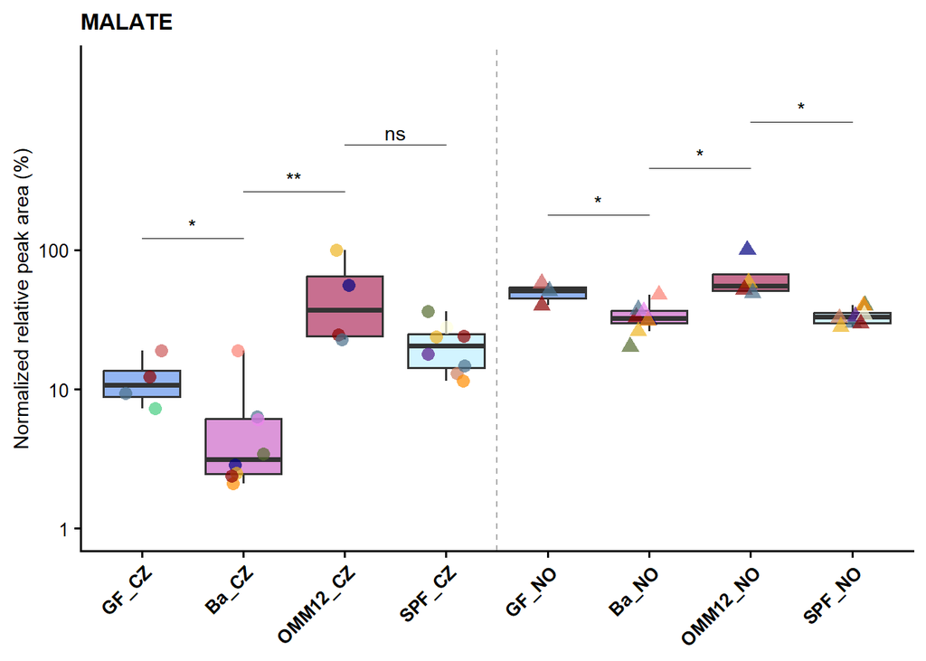

```r
ggplot(malate, aes(x = COHORT, y = `MEDIAN_REL_AREA_NORMALIZED`, fill = COHORT)) +
  geom_boxplot(alpha = 0.7, outlier.shape = NA,show.legend = FALSE) +
  geom_vline(xintercept = 4.5, linetype = "dashed", linewidth = 0.5, color = "darkgrey") +
  geom_jitter(aes(color = TYPE, shape = COUNTRY), width = 0.2, size = 3, alpha = 0.7, show.legend = FALSE) +
  stat_compare_means(comparisons = malate_comparisons,
                     method = "t.test",
                     label = "p.signif",
                     p.adjust.method = "BH",
                     tip.length = 0.00,
                     step.increase = 0.1) +
  scale_color_manual(values = my_palette_color) +
  scale_shape_manual(values = c("CZ" = 16, "NO" = 17)) +
  scale_fill_manual(values = my_palette_fill) +
  scale_y_log10(breaks = c(0.1, 1, 10, 100),
                labels = c("0.1", "1", "10", "100")) +
  coord_cartesian(ylim = c(1, 2000)) +  # keeps all points in view without dropping
  theme_classic(base_size = 14) +
  labs(title = "MALATE", y = "Normalized relative peak area (%)")+
   theme(
    plot.title   = element_text(size = 12, face = "bold"),
    axis.title.x = element_blank(),
    axis.title.y = element_text(size = 11, colour = "black"),
    axis.text.x  = element_text(size = 10, face = "bold", angle = 45, hjust = 1, colour = "black"),
    axis.text.y  = element_text(size = 10, colour = "black")
  )
```

Save as a variavble

```r
Malate_boxplots<- ggplot(malate, aes(x = COHORT, y = `MEDIAN_REL_AREA_NORMALIZED`, fill = COHORT)) +
  geom_boxplot(alpha = 0.7, outlier.shape = NA,show.legend = FALSE) +
  geom_vline(xintercept = 4.5, linetype = "dashed", linewidth = 0.5, color = "darkgrey") +
  geom_jitter(aes(color = TYPE, shape = COUNTRY), width = 0.2, size = 1.5, alpha = 0.7, show.legend = FALSE) +
  stat_compare_means(comparisons = malate_comparisons,
                     method = "t.test",
                     label = "p.signif",
                     p.adjust.method = "BH",
                     tip.length = 0.00,
                     step.increase = 0.1) +
  scale_color_manual(values = my_palette_color) +
  scale_shape_manual(values = c("CZ" = 16, "NO" = 17)) +
  scale_fill_manual(values = my_palette_fill) +
  scale_y_log10(breaks = c(0.1, 1, 10, 100),
                labels = c("0.1", "1", "10", "100")) +
  coord_cartesian(ylim = c(1, 2000)) +  # keeps all points in view without dropping
  theme_classic(base_size = 14) +
  labs(title = "MALATE", y = "Normalized relative peak area (%)")+
   theme(
    plot.title   = element_text(size = 12, face = "bold"),
    axis.title.x = element_blank(),
    axis.title.y = element_text(size = 11, colour = "black"),
    axis.text.x  = element_text(size = 10, face = "bold", angle = 45, hjust = 1, colour = "black"),
    axis.text.y  = element_text(size = 10, colour = "black")
  )
ggsave("Malate_boxplots.png",
       plot = Malate_boxplots,
       width = 10, height = 10, dpi = 300)
```

S U C C I N A T E